# 循环

# 目录

- 1 前提准备
- 2 `for` 循环
- 3 `for` 循环的变种
  - 3.1 修改已存在的对象
  - 3.2 不同的循环方式
  - 3.3 输出长度未知
  - 3.4 序列（循环次数）长度未知
- 4 `for` 循环与函数的比较
- 5 `map` 函数族
  - 5.1 `.f` 的快捷操作
  - 5.2 原生 R
- 6 处理报错
- 7 同时对多个向量循环
  - 7.1 运用不同的函数
- 8 `walk` 函数
- 9 其他类型的循环
  - 9.1 预测函数（Predicate functions）
  - 9.2 `reduce()` 函数和 `accumulate()` 函数

# 1 前提准备

```r
library(tidyverse)
```

# 2 `for` 循环

假设有以下数据集：

```r
df <- tibble(
  a = rnorm(10),
  b = rnorm(10),
  c = rnorm(10),
  d = rnorm(10)
)
```

计算每一列的中位数：

```r
median(df$a)
```

```
[1] 0.01903167
```

```r
median(df$b)
```

```
[1] -0.417754
```

```r
median(df$c)
```

```
[1] 0.3794763
```

```r
median(df$d)
```

```
[1] 0.04256056
```

这种方法违背了最重要的准则：不要复制粘贴超过两次。因此，使用 `for` 循环：

```r
output <- vector("double", ncol(df))  # 1. output
for (i in seq_along(df)) {            # 2. sequence
  output[[i]] <- median(df[[i]])      # 3. body
}
output
```

```
[1]  0.01903167 -0.41775398  0.37947632  0.04256056
```

`for` 循环中有3个组成部分：

- 1 **输出（output）**： `output <- vector("double", length(x))`  
  开始 `for` 循环之前，必须为输出分配好足够的空间。使用 `c()` 来保存输出效率非常低下，通常使用 `vector()` 创建合适长度的空向量。 `vector()` 有2个参数：向量的数据类型（“logical” 、 “integer” 、 “double” 、 “character” 等）和向量的长度。
- 2 **序列（sequence）**： `i in seq_along(df)`  
  决定循环的次数，每次循环都会依次从 `seq_along(df)` 中提取不同的值赋给 `i` 。 `seq_along()` 的作用与 `1:length(l)` 相似，区别在于向量长度为0时， `seq_along()` 不会产生错误：

```r
y <- vector("double", 0)
seq_along(y)
```

```
integer(0)
```

```r
1:length(y)
```

```
[1] 1 0
```

- 3 **循环体（body）**： `output[[i]] <- median(df[[i]])`  
  循环中具体执行的操作。每次循环中 `i` 的值都不同。

# 3 `for` 循环的变种

## 3.1 修改已存在的对象

例如，我们想归一化数据框中的每一列。使用函数可以达到这一目的：

```r
df <- tibble(
  a = rnorm(10),
  b = rnorm(10),
  c = rnorm(10),
  d = rnorm(10)
)
rescale01 <- function(x) {
  rng <- range(x, na.rm = TRUE)
  (x - rng[1]) / (rng[2] - rng[1])
}
df$a <- rescale01(df$a)
df$b <- rescale01(df$b)
df$c <- rescale01(df$c)
df$d <- rescale01(df$d)
```

使用 `for` 循环来进行归一化：

```r
for (i in seq_along(df)) {
  df[[i]] <- rescale01(df[[i]])
}
```

此处应该使用 `[[` 而非 `[` ，以明确每一次循环只对单一元素进行处理。

## 3.2 不同的循环方式

通常有3种构建循环的方式：

- 1 用位置索引循环： `for (i in seq_along(xs))` 和 `x[[i]]`
- 2 用元素循环： `for (x in xs)`
- 3 用元素名循环： `for (nm in names(xs))` 和 `x[[nm]]` 使用元素名循环，在创建输出的时候，可以提前对输出向量命名：

  ```
  results <- vector("list", length(x))
  names(results) <- names(x)
  ```

相比之下，第一种方式最为常见，可以通过位置索引得到元素名和元素值：

```
for (i in seq_along(x)) {
  name <- names(x)[[i]]
  value <- x[[i]]
}
```

## 3.3 输出长度未知

有时候，循环的输出长度并不确定。例如，生成长度随机的随机数向量，可以使用 `c()` 创建输出：

```r
means <- c(0, 1, 2)
output <- double()
for (i in seq_along(means)) {
  n <- sample(100, 1)
  output <- c(output, rnorm(n, means[[i]]))
}
str(output)
```

```
 num [1:111] -0.0474 0.233 1.5355 0.9178 1.9185 ...
```

更有效率的方式是用列表保存输出，并在循环结束后将其组合到一个向量中：

```r
out <- vector("list", length(means))
for (i in seq_along(means)) {
  n <- sample(100, 1)
  out[[i]] <- rnorm(n, means[[i]])
}
str(out)
```

```
List of 3
 $ : num [1:59] 0.117 -0.208 -1.137 -0.488 -1.339 ...
 $ : num [1:15] 0.815 1.191 -0.128 0.977 1.537 ...
 $ : num [1:41] -0.171 0.443 3 2.732 2.706 ...
```

```r
str(unlist(out))
```

```
 num [1:115] 0.117 -0.208 -1.137 -0.488 -1.339 ...
```

使用 `unlist()` 可以将列表扁平化为向量。使用 `purrr::flatten_dbl()` 更为安全，它会在输出不是双精度列表时报错。

以下情况也会用到类似的方法：

- 生成长字符串  
  将输出保存在字符向量中，并在循环结束后用 `paste(output, collapse = "")` 将其组合成一个字符串
- 生成数据框  
  将输出保存在列表中，并在循环结束后用 `dplyr::bind_rows(output)` 将其组合成一个数据框

## 3.4 序列（循环次数）长度未知

有时候，循环的次数并不确定。例如，直到达成某种条件才停止循环。此时，可以使用 `while` 循环：

```
while (condition) {
  # body
}
```

`while` 循环比 `for` 循环的适用范围更广，所有 `for` 循环都可以改写成 `while` 循环，反之则不然：

```
for (i in seq_along(x)) {
  # body
}

# Equivalent to
i <- 1
while (i <= length(x)) {
  # body
  i <- i + 1
}
```

以下代码计算抛硬币多少次后得到三个“头”：

```r
flip <- function() sample(c("T", "H"), 1)
flips <- 0
nheads <- 0
while (nheads < 3) {
  if (flip() == "H") {
    nheads <- nheads + 1
  } else {
    nheads <- 0
  }
  flips <- flips + 1
}
flips
```

```
[1] 32
```

# 4 `for` 循环与函数的比较

由于 R 是函数式编程语言， `for` 循环可以被组装成函数，用下面的例子来说明：

```r
df <- tibble(
  a = rnorm(10),
  b = rnorm(10),
  c = rnorm(10),
  d = rnorm(10)
)
```

求出数据框中每列的平均数，用 `for` 循环来表达：

```r
output <- vector("double", length(df))
for (i in seq_along(df)) {
  output[[i]] <- mean(df[[i]])
}
output
```

```
[1]  0.4124969 -0.1718229 -0.2371201  0.4959519
```

将 `for` 循环组装成函数 `col_mean` ，方便对其他数据框进行同样的计算：

```r
col_mean <- function(df) {
  output <- vector("double", length(df))
  for (i in seq_along(df)) {
    output[i] <- mean(df[[i]])
  }
  output
}
```

同样的，可以编写求中位数、标准差的函数 `col_median` 、 `col_sd` ：

```r
col_median <- function(df) {
  output <- vector("double", length(df))
  for (i in seq_along(df)) {
    output[i] <- median(df[[i]])
  }
  output
}
```

```r
col_sd <- function(df) {
  output <- vector("double", length(df))
  for (i in seq_along(df)) {
    output[i] <- sd(df[[i]])
  }
  output
}
```

但是这样的做法违背了我们的准则：不要复制粘贴超过两次！因此将这3个函数抽象成一个函数 `col_summary` ：

```r
col_summary <- function(df, fun) {
  out <- vector("double", length(df))
  for (i in seq_along(df)) {
    out[i] <- fun(df[[i]])
  }
  out
}
```

```r
col_summary(df, median)
```

```
[1]  0.5351462 -0.2179740 -0.3083132  0.5942196
```

```r
col_summary(df, mean)
```

```
[1]  0.4124969 -0.1718229 -0.2371201  0.4959519
```

将一个函数作为参数传递给另一个函数，是 R 语言作为函数式编程语言的特性之一

# 5 `map` 函数族

在一个原子向量或列表中进行循环，对每个元素进行同样的操作并返回结果，这样的操作在 R 中很常见。因此， `purrr` 包提供了一个函数族来应对这种情况：

- `map()`：返回列表
- `map_lgl()`：返回逻辑向量
- `map_int()`：返回整数向量
- `map_dbl()`：返回双精度向量
- `map_chr()`：返回字符向量

每一个函数都接受向量（原子向量或迭代向量）作为输入，对每个元素进行同样的操作，并返回与输入的向量长度、名字相同的向量（原子向量或迭代向量）。返回向量的具体类型取决于函数的后缀。 `map()` 函数的优点不在于速度更快，而在于代码更加简洁易读。  
上一节中的 `col_summary()` 函数可以通过 `map_dbl()` 改写：

```r
map_dbl(df, mean)
```

```
         a          b          c          d
 0.4124969 -0.1718229 -0.2371201  0.4959519
```

```r
map_dbl(df, median)
```

```
         a          b          c          d
 0.5351462 -0.2179740 -0.3083132  0.5942196
```

```r
map_dbl(df, sd)
```

```
        a         b         c         d
0.6691846 1.3167386 0.9226259 1.3390682
```

使用管道操作符，代码将会更加清晰：

```r
df %>% map_dbl(mean)
```

```
         a          b          c          d
 0.4124969 -0.1718229 -0.2371201  0.4959519
```

```r
df %>% map_dbl(median)
```

```
         a          b          c          d
 0.5351462 -0.2179740 -0.3083132  0.5942196
```

```r
df %>% map_dbl(sd)
```

```
        a         b         c         d
0.6691846 1.3167386 0.9226259 1.3390682
```

`map_*()` 与自定义 `col_summary()` 函数的差别在于：

- `purrr` 包由 `C` 语言实现，速度稍快
- 第二个参数 `.f` 不仅仅可以是函数，还可以是公式（formula）、字符向量、整数向量
- `map_*()` 中使用 `...` ，因此可以为 `.f` 添加额外的参数

```r
map_dbl(df, mean, trim = 0.5)
```

```
         a          b          c          d
 0.5351462 -0.2179740 -0.3083132  0.5942196
```

- `map_*()` 函数会保留元素名

```r
z <- list(x = 1:3, y = 4:5)
map_int(z, length)
```

```
x y
3 2
```

## 5.1 `.f` 的快捷操作

- 公式  
  假设想要依据 `cyl` 变量的取值对 `mtcars` 数据集进行分组，并对每组数据分别建立线性回归：

```r
models <- mtcars %>%
  split(.$cyl) %>%
  map(function(df) lm(mpg ~ wt, data = df))
```

返回的结果是长度为3列表，元素分别是不同组别的线性回归模型：

```r
models
```

```
$`4`

Call:
lm(formula = mpg ~ wt, data = df)

Coefficients:
(Intercept)           wt
     39.571       -5.647


$`6`

Call:
lm(formula = mpg ~ wt, data = df)

Coefficients:
(Intercept)           wt
      28.41        -2.78


$`8`

Call:
lm(formula = mpg ~ wt, data = df)

Coefficients:
(Intercept)           wt
     23.868       -2.192
```

由于在 R 中匿名函数的写法比较麻烦， `purrr` 提供了快捷操作，在 `map()` 中使用公式（formula）参数：

```r
models <- mtcars %>%
  split(.$cyl) %>%
  map(~lm(mpg ~ wt, data = .))
```

这里 `.` 是占位符，指代当前正在处理中的向量的元素。

- 字符串  
  假设要得到每个模型的 \(r^2\) ,同样可以在 `map_dbl()` 中使用公式参数。 `.` 是占位符，指代当前正在处理中的向量的元素：

```r
models %>%
  map(summary) %>%
  map_dbl(~.$r.squared)
```

```
        4         6         8
0.5086326 0.4645102 0.4229655
```

由于提取命过名的元素是常见的操作，所以 `purrr` 提供了更为快捷的操作方法，在 `map_*()` 中使用字符串参数：

```r
models %>%
  map(summary) %>%
  map_dbl("r.squared")
```

```
        4         6         8
0.5086326 0.4645102 0.4229655
```

- 整数 也可以在 `map_*()` 中使用代表位置的整数索引：

```r
x <- list(list(1, 2, 3), list(4, 5, 6), list(7, 8, 9))
x %>% map_dbl(2)
```

```
[1] 2 5 8
```

## 5.2 原生 R

原生 R 中的 `apply` 函数族与 `purrr` 包中的 `map` 函数族功能类似：

```r
x1 <- list(
  c(0.27, 0.37, 0.57, 0.91, 0.20),
  c(0.90, 0.94, 0.66, 0.63, 0.06),
  c(0.21, 0.18, 0.69, 0.38, 0.77)
)
x2 <- list(
  c(0.50, 0.72, 0.99, 0.38, 0.78),
  c(0.93, 0.21, 0.65, 0.13, 0.27),
  c(0.39, 0.01, 0.38, 0.87, 0.34)
)
x3 <- list(
  c(0.50, 0.92, 0.99, 0.38, 0.88),
  c(0.93, 0.21, 0.65, 0.93, 0.27),
  c(0.39, 1.01, 0.38, 0.97, 0.34)
)
threshold <- function(x, cutoff = 0.8) x[x > cutoff]
```

```r
x1 %>% sapply(threshold)
```

```
[[1]]
[1] 0.91

[[2]]
[1] 0.90 0.94

[[3]]
numeric(0)
```

```r
x2 %>% sapply(threshold)
```

```
[1] 0.99 0.93 0.87
```

```r
x3 %>% sapply(threshold, 0.9)
```

```
     [,1] [,2] [,3]
[1,] 0.92 0.93 1.01
[2,] 0.99 0.93 0.97
```

- `vapply()` 相比 `sapply()` 更加安全，可以通过 `FUN.VALUE` 参数限定输出的数据类型和长度。  
  `vapply()` 的缺点在于代码长， `vapply(df, is.numeric, logical(1))` 的作用与 `map_lgl(df, is.numeric)` 相同，优点在于可以生成矩阵，而 `map` 函数族只能生成列表或向量。

# 6 处理报错

使用 `map` 函数进行循环操作，其中任意一步操作失败，都会报错而得不到任何结果。

- 使用 `safely()` 函数，不会得到报错，而会返回2个元素的列表：
  - `result` ： 循环操作的结果，如果循环过程中产生错误，该元素为 `NULL`
  - `error` ： `error` 对象，如果整个操作成功，该元素为 `NULL`

`safely()` 函数与 R 中的 `try()` 函数类似，但是 `try()` 函数有时返回结果有时返回 `error` 对象，因而 `safely()` 更易用。

```r
safe_log <- safely(log)
str(safe_log(10))
```

```
List of 2
 $ result: num 2.3
 $ error : NULL
```

```r
str(safe_log("a"))
```

```
List of 2
 $ result: NULL
 $ error :List of 2
  ..$ message: chr "non-numeric argument to mathematical function"
  ..$ call   : language .f(...)
  ..- attr(*, "class")= chr [1:3] "simpleError" "error" "condition"
```

`safely()` 被设计用于 `map()` 函数，某一步骤操作失败，不会影响循环中其他步骤的操作：

```r
x <- list(1, 10, "a")
y <- x %>% map(safely(log))
str(y)
```

```
List of 3
 $ :List of 2
  ..$ result: num 0
  ..$ error : NULL
 $ :List of 2
  ..$ result: num 2.3
  ..$ error : NULL
 $ :List of 2
  ..$ result: NULL
  ..$ error :List of 2
  .. ..$ message: chr "non-numeric argument to mathematical function"
  .. ..$ call   : language .f(...)
  .. ..- attr(*, "class")= chr [1:3] "simpleError" "error" "condition"
```

- `purrr::transpose()` 函数会将 `safely()` 的结果转化为由2个子列表构成的列表，一个子列表包含 `result` ，一个子列表包含 `error` ：

```r
y <- y %>% transpose()
str(y)
```

```
List of 2
 $ result:List of 3
  ..$ : num 0
  ..$ : num 2.3
  ..$ : NULL
 $ error :List of 3
  ..$ : NULL
  ..$ : NULL
  ..$ :List of 2
  .. ..$ message: chr "non-numeric argument to mathematical function"
  .. ..$ call   : language .f(...)
  .. ..- attr(*, "class")= chr [1:3] "simpleError" "error" "condition"
```

查看 `x` 中哪些值导致 `y` 返回 `error` 对象：

```r
is_ok <- y$error %>% map_lgl(is_null)
x[!is_ok]
```

```
[[1]]
[1] "a"
```

对返回正常结果的 `y` 进行下一步操作：

```r
y$result[is_ok] %>% flatten_dbl()
```

```
[1] 0.000000 2.302585
```

- `purrr::possibly()` 函数功能比 `safely()` 函数相对简单，它可以设置一个默认值，对操作失败的步骤赋予该默认值：

```r
x <- list(1, 10, "a")
x %>% map_dbl(possibly(log, NA_real_))
```

```
[1] 0.000000 2.302585       NA
```

- `purrr::quietly()` 函数功能与 `safely()` 函数类似，但是它不返回 `error` ，而是返回打印的输出（printed output）、 `messages` 和 `warnings` ：

```r
x <- list(1, -1)
x %>% map(quietly(log)) %>% str()
```

```
List of 2
 $ :List of 4
  ..$ result  : num 0
  ..$ output  : chr ""
  ..$ warnings: chr(0)
  ..$ messages: chr(0)
 $ :List of 4
  ..$ result  : num NaN
  ..$ output  : chr ""
  ..$ warnings: chr "NaNs produced"
  ..$ messages: chr(0)
```

# 7 同时对多个向量循环

用 `map()` 函数可以生成均值不同的正态分布随机数：

```r
mu <- list(5, 10, -3)
mu %>%
  map(rnorm, n = 5) %>%
  str()
```

```
List of 3
 $ : num [1:5] 4.13 5.99 5.95 4.97 3.78
 $ : num [1:5] 8.16 9.87 8.83 8.68 10.07
 $ : num [1:5] -2.894 -0.901 -2.714 -4.58 -1.915
```

如果要生成均值不同、方差不同的正态分布随机数该如何做？用 `map()` 函数可以利用整数索引同时对均值向量、方差向量循环：

```r
sigma <- list(1, 5, 10)
seq_along(mu) %>%
  map(~rnorm(5, mu[[.]], sigma[[.]])) %>%
  str()
```

```
List of 3
 $ : num [1:5] 4.62 5.24 5.96 4.9 2.59
 $ : num [1:5] 13.28 4.9 5.97 13.57 3.95
 $ : num [1:5] 5.13 2.12 -17.23 -20.57 5.85
```

- `map2()` 函数

以上方法过于繁琐，使用 `map2()` 函数可以方便地同时对2个向量循环。注意，需要变化的参数在函数之前，不变的参数在函数之后：

```r
map2(mu, sigma, rnorm, n = 5) %>% str()
```

```
List of 3
 $ : num [1:5] 5.08 4.88 4.47 6.08 6.55
 $ : num [1:5] -1.51 5.65 1.82 10.69 4.36
 $ : num [1:5] -6.957 -11.548 -9.923 -0.548 14.058
```

`map2()` 函数的工作原理如下：

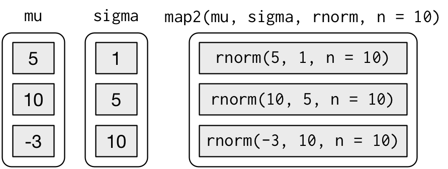

同 `map()` 一样， `map2()` 仅仅是对 `for` 循环的封装：

```
map2 <- function(x, y, f, ...) {
  out <- vector("list", length(x))
  for (i in seq_along(x)) {
    out[[i]] <- f(x[[i]], y[[i]], ...)
  }
  out
}
```

- `pmap()` 函数

`pmap()` 函数可以接受一个参数列表，实现同时对多个向量循环。例如，生成均值不同、方差不同、长度不同的正态分布随机数：

```r
n <- list(1, 3, 5)
args1 <- list(n, mu, sigma)
args1 %>%
  pmap(rnorm) %>%
  str()
```

```
List of 3
 $ : num 5.35
 $ : num [1:3] 18.38 9.15 13.68
 $ : num [1:5] -29.05 -4.81 4.5 -3.17 4.94
```

`pmap()` 函数的工作原理如下：

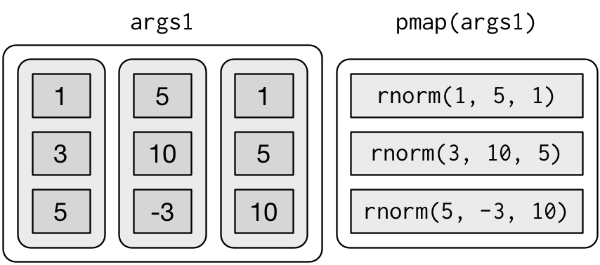

上面的代码中，参数列表并未命名， `pmap()` 函数默认根据位置判断函数的参数对应列表中的哪个向量。通过为参数列表中的元素命名，可以使程序不易犯错：

```r
args2 <- list(mean = mu, sd = sigma, n = n)
args2 %>%
  pmap(rnorm) %>%
  str()
```

```
List of 3
 $ : num 5.96
 $ : num [1:3] 6.695 0.388 7.406
 $ : num [1:5] -3.84 -13.81 8.08 -13.81 -18
```

工作原理如下：

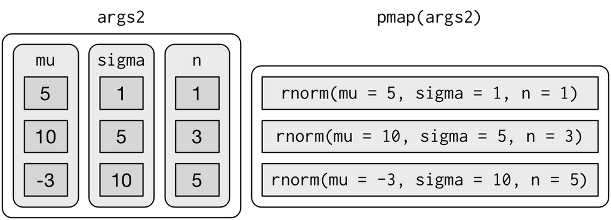

由于多个向量的长度一定相同，也可以将向量存储在带有列名的数据框中：

```r
params <- tribble(
  ~mean, ~sd, ~n,
    5,     1,  1,
   10,     5,  3,
   -3,    10,  5
)
params %>%
  pmap(rnorm)
```

```
[[1]]
[1] 4.112286

[[2]]
[1]  3.108836 12.072195  8.984829

[[3]]
[1] -9.8142825 -6.5615928  0.8362571 -3.8998941  5.5742156
```

## 7.1 运用不同的函数

有时候不仅仅要同时对多个向量循环，对不同向量还要运用不同的函数，使用 `invoke_map()` 函数可以做到这一点：

```r
f <- c("runif", "rnorm", "rpois")
param <- list(
  list(min = -1, max = 1),
  list(sd = 5),
  list(lambda = 10)
)
```

```r
invoke_map(f, param, n = 5) %>% str()
```

```
List of 3
 $ : num [1:5] -0.684 -0.327 -0.442 0.787 -0.761
 $ : num [1:5] 7.05 -7.5 -6.14 -2.24 -1.89
 $ : int [1:5] 11 12 15 9 17
```

`invoke_map()` 函数的工作原理如下：

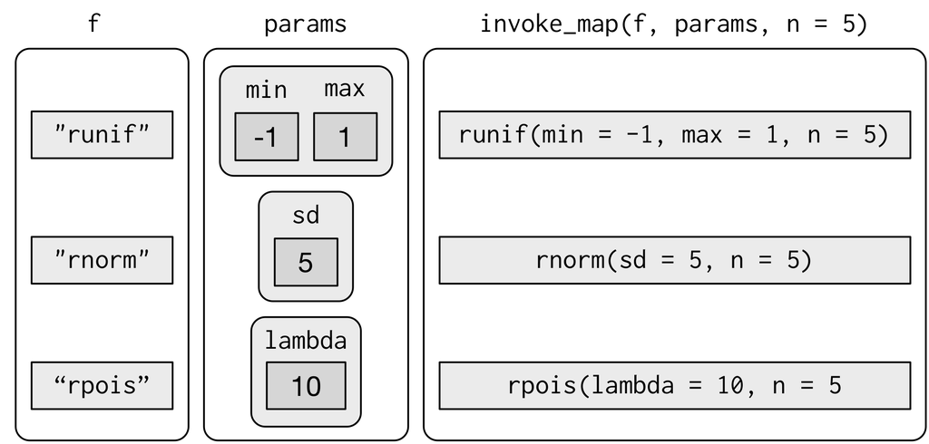

第一个参数是函数的列表或函数名的字符向量；第二个参数是参数的列表，每个子列表中的参数对应一个函数；剩下的参数会应用于每个函数。

同 `pmap()` 函数一样，`invoke_map()` 中的函数和参数也可以存储在数据框中：

```r
sim <- tribble(
  ~f,      ~params,
  "runif", list(min = -1, max = 1),
  "rnorm", list(sd = 5),
  "rpois", list(lambda = 10)
)
sim %>%
  mutate(sim = invoke_map(f, params, n = 10))
```

| f | params | sim |
| --- | --- | --- |
| runif |  |  |
| rnorm |  |  |
| rpois |  |  |

```
#> # A tibble: 3 × 3
#>       f     params        sim
#>   <chr>     <list>     <list>
#> 1 runif <list [2]> <dbl [10]>
#> 2 rnorm <list [1]> <dbl [10]>
#> 3 rpois <list [1]> <int [10]>
```

# 8 `walk` 函数

如果要得到的不是返回值，而是要执行打印、画图、存储文件等动作，可以使用 `walk()` 函数：

```r
x <- list(1, "a", 3)
x %>%
  walk(print)
```

```
[1] 1
[1] "a"
[1] 3
```

同样的， `walk()` 函数也有对应的 `walk2()` 、 `pwalk()` 函数。例如，将多张图保存在对应的路径中：

```r
library(ggplot2)
plots <- mtcars %>%
  split(.$cyl) %>%
  map(~ggplot(., aes(mpg, wt)) + geom_point())
paths <- stringr::str_c(names(plots), ".pdf")
pwalk(list(paths, plots), ggsave, path = tempdir())
```

`walk()` 、 `walk2()` 和 `pwalk()` 都会使用 `invisible()` 函数返回输入的第一个参数 `.x` ，因而适用于管道操作符。

# 9 其他类型的循环

## 9.1 预测函数（Predicate functions）

某些预测函数（**predicate** functions）会返回标量 `TRUE` 或 `FALSE` 。

- `keep()` 和 `discard()` 分别会保留返回值为 `TRUE` 或 `FALSE` 的元素：

```r
iris %>%
  keep(is.factor) %>%
  str()
```

```
'data.frame':   150 obs. of  1 variable:
 $ Species: Factor w/ 3 levels "setosa","versicolor",..: 1 1 1 1 1 1 1 1 1 1 ...
```

```r
iris %>%
  discard(is.factor) %>%
  str()
```

```
'data.frame':   150 obs. of  4 variables:
 $ Sepal.Length: num  5.1 4.9 4.7 4.6 5 5.4 4.6 5 4.4 4.9 ...
 $ Sepal.Width : num  3.5 3 3.2 3.1 3.6 3.9 3.4 3.4 2.9 3.1 ...
 $ Petal.Length: num  1.4 1.4 1.3 1.5 1.4 1.7 1.4 1.5 1.4 1.5 ...
 $ Petal.Width : num  0.2 0.2 0.2 0.2 0.2 0.4 0.3 0.2 0.2 0.1 ...
```

- `some()` 和 `every()` 分别判断返回值中是否存在 `TRUE` 或是否全为 `TRUE` ：

```r
x <- list(1:5, letters, list(10))
x %>%
  some(is_character)
```

```
[1] TRUE
```

```r
x %>%
  every(is_vector)
```

```
[1] TRUE
```

- `detect()` 函数返回第一个预测为 `TRUE` 的元素， `detect_index()` 返回该元素的位置：

```r
x <- sample(10)
x
```

```
 [1]  4  5  9  7 10  8  2  3  1  6
```

```r
x %>%
  detect(~ . > 5)
```

```
[1] 9
```

```r
x %>%
  detect_index(~ . > 5)
```

```
[1] 3
```

- `head_while()` 和 `tail_while()` 从向量的开头或结尾开始搜寻，找出连续的预测为 `TRUE` 的元素：

```r
x %>%
  head_while(~ . > 5)
```

```
integer(0)
```

```r
x %>%
  tail_while(~ . > 5)
```

```
[1] 6
```

## 9.2 `reduce()` 函数和 `accumulate()` 函数

- `reduce()` 函数接受一个二元函数和一个列表，对列表内的元素重复使用该二元函数，直到只剩下一个元素

例如，将多个数据库联结成一个数据框：

```r
dfs <- list(
  age = tibble(name = "John", age = 30),
  sex = tibble(name = c("John", "Mary"), sex = c("M", "F")),
  trt = tibble(name = "Mary", treatment = "A")
)
dfs %>% reduce(full_join)
```

| name | age | sex | treatment |
| --- | --- | --- | --- |
| John | 30 | M | NA |
| Mary | NA | F | A |

```
#> # A tibble: 2 × 4
#>    name   age   sex treatment
#>   <chr> <dbl> <chr>     <chr>
#> 1  John    30     M      <NA>
#> 2  Mary    NA     F         A
```

寻找一组向量的交集：

```r
vs <- list(
  c(1, 3, 5, 6, 10),
  c(1, 2, 3, 7, 8, 10),
  c(1, 2, 3, 4, 8, 9, 10)
)
vs %>% reduce(intersect)
```

```
[1]  1  3 10
```

- `accumulate()` 函数的功能与 `reduce()` 函数类似，但是会保留所有的中间结果

求向量的累积和：

```r
x <- sample(10)
x
```

```
 [1]  9  5 10  3  6  8  1  7  2  4
```

```r
x %>% accumulate(`+`)
```

```
 [1]  9 14 24 27 33 41 42 49 51 55
```